# Transcriptomics

[figure not shown]

> Welkom bij het Transcriptomics werkcollege! In deze tutorial leer je stap voor stap hoe RNA-seq data verwerkt wordt — van raw reads tot differentiële genexpressie.

## Leerdoelen

In deze werkcolleges en tijdens de casus ga je bezig met de volgende onderdelen:

- Je mapt reads met het Rsubread package in R.
- Je bepaalt verschillen in genexpressie met het DESeq2 package in R.
- Je bepaalt verschillen in KEGG pathways in R.

Niet tijdens deze werkcolleges, maar wel voor je casusopdracht:

- Je bepaalt verschillen in gene ontologies in R.
- Je legt uit hoe je onderzoeksgegevens en scripts kan beheren.
- Je voert een project uit waarbij je als data steward de projectgegevens beheert.
- Je legt uit hoe je als data steward projectgegevens hebt beheerd.

In het onderstaande flowschema is het overzicht van de werkcolleges te zien. Per werkcollege kan je terugzien welke onderdelen bij elk werkcollege horen.

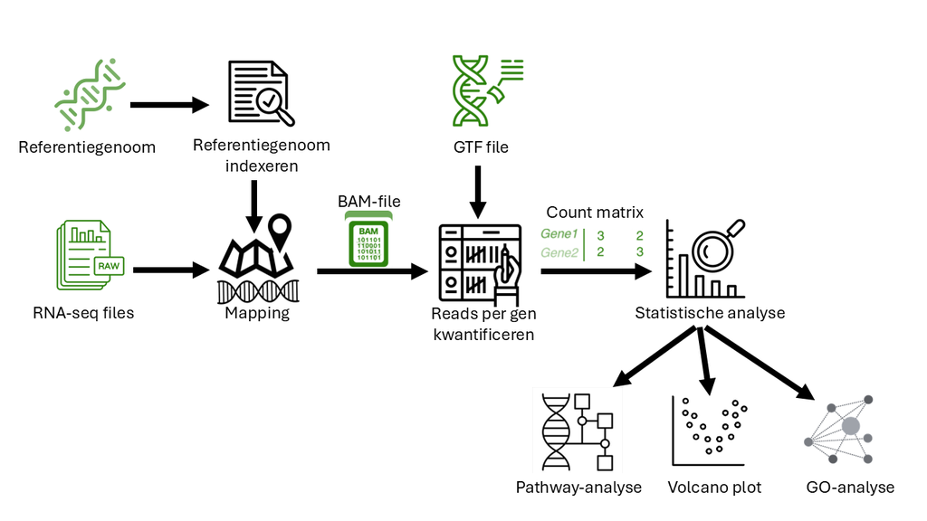

# Werkcollege 1: Mapping

Tijdens dit eerste werkcollege maak je een begin aan het analyseren van RNA-Seq data. We gaan reads mappen, zodat we weten waar deze zich op het referentiegenoom. In onderstaand flowschema is te zien met welke stappen we vandaag bezig gaan.

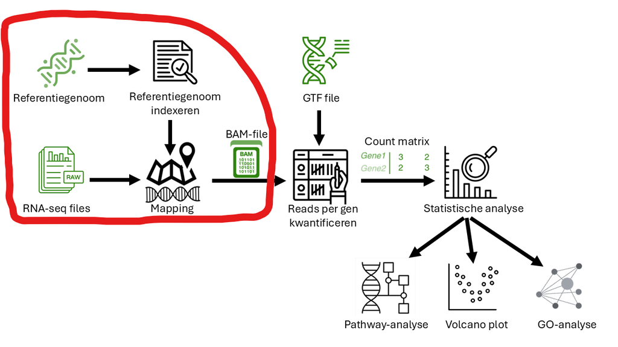

> **Tip**: houd tijdens de werkcolleges een script bij met duidelijke documentatie. Hierdoor heb je een goede basis voor de casus.

## Dataset

Desinfecterende middelen en antiseptica spelen een cruciale rol bij het beheersen en elimineren van ziekteverwekkers, vooral in omgevingen zoals ziekenhuizen en de voedselindustrie. Deze producten worden op grote schaal gebruikt, maar de regelgeving rondom hun toepassing is vaak gebrekkig. Soms treden er uitbraken op van micro-organismen die resistent zijn geworden tegen deze middelen. Ondanks gebruik, is er nog veel onbekend over hoe bacteriën reageren op deze chemische stoffen en hoe ze resistentie ontwikkelen.

Voor deze werkcolleges gebruiken we data uit *Pereira et al. (2020)*. Je kunt dit artikel vinden op BlackBoard. Het doel van dit onderzoek was om via Transcriptomics analyse (RNA-sequencing) inzicht te krijgen welke genen geactiveerd of onderdrukt worden bij Escherichia coli tijdens blootstelling aan biociden, waaronder ethanol. Wij gaan alleen blootstelling aan ehtanol analyseren in deze werkcolleges.

Ruwe data uit artikelen wordt in verband met reproduceerbaarheid/transparantie vaak openbaar gezet. Vaak kan je sequencing data uit artikelen terugvinden in het [Sequence Read Archive van NCBI](https://www.ncbi.nlm.nih.gov/sra). Voor genexpressie data kan je vaak terecht bij [Gene expression omnibus van NCBI](https://www.ncbi.nlm.nih.gov/geo/). In een artikel wordt dan genoemd onder welke code je de data kan vinden en waar. Probeer in het artikel van Pereira et al. (2020) eens te vinden waar ze de data hebben opgeslagen. Klik hieronder op **hint** als je het niet kunt vinden. Je kunt het antwoord zien als je op **antwoord** klikt.

**Hint**

Vaak staat helemaal onderaan een artikel weergeven waar je de gebruikte data kunt vinden. Een handige truc kan ook zijn om te zoeken op woorden zoals *availability* of *accession* met `Ctrl + F`.

**Antwoord**

Op pagina 15 is te zien dat de RNAseq data beschikbaar is gemaakt in GEO (Gene expression omnibus) met de code *GSE124673*. Deze code kan je opzoeken, waardoor je op [deze pagina](https://www.ncbi.nlm.nih.gov/geo/query/acc.cgi?acc=GSE124673) uitkomt. Je ziet onder het kopje *Samples* alle samples staan.

Het downloaden van de data kan even duren. Daarom zijn de benodigde bestanden alvast beschikbaar gesteld. Download de gezipte folder **Raw_Wcs_Transcriptomics.zip** van BlackBoard. Er zijn in totaal zes databestanden (drie controle, drie ethanol). Pak de gedownloade data uit in een apart mapje voor de Transcriptomics werkcolleges zodat je dit later terug kunt vinden. Doe dit op bijvoorbeeld OneDrive. Je kunt alvast doorgaan met de volgende stap tot het downloaden klaar is. Hieronder een overzicht met informatie over de samples die we gaan analyseren:

[output not shown]

### Instellen working directory

Stel je working directory in. Een working directory in R is de standaardmap (folder) waarin R zoekt naar bestanden en waar het bestanden opslaat, tenzij je een volledig pad opgeeft. Dit kan op twee manieren in Rstudio:

1. Met de functie `setwd()`

```r
setwd("C:/Users/jouw_naam/Documents/Transcriptomics")
```

Je kunt de `tab` toets gebruiken om namen automatisch aan te laten vullen.

2. Handmatig (kan bijvoorbeeld handiger zijn met een Macbook):
- Ga in RStudio naar de *Session tab*.
- Navigeer naar *Set Working Directory*.
- Klik op *Choose Directory*.
- Kies de gewenste map.

Nu kunnen we echt beginnen. Check nog even of je working directory staat ingesteld op de folder waar je ruwe data in staat.

```r
getwd()
```

## Packages

Wereldwijd ontwikkelen onderzoeksgroepen nieuwe analyseprogramma’s voor R. `Bioconductor` is een verzameling van R-packages die speciaal ontwikkeld zijn voor de analyse van biologische data, zoals sequencing data (bijv. RNA-seq, DNA-seq).

Voordat je deze tools kunt gebruiken, moet je eerst `Bioconductor` installeren. Dit doe je via het package BiocManager, waarmee je eenvoudig Bioconductor-packages kunt downloaden en updaten binnen R.

```r
install.packages('BiocManager')
```

Installeer en laad het package `Rsubread`. Probeer dit eerst zelf door onderstaande code aan te vullen. Klik op **Antwoord** als je er niet uit komt of wilt checken of je het goed hebt gedaan.

```r
# Package downloaden
BiocManager::install('PACKAGE NAAM')
# Package laden
...(PACKAGE NAAM)
```

**Antwoord**

```r
# Package downloaden
BiocManager::install('Rsubread')
# Package laden
library(Rsubread)
```

We weten natuurlijk nog niet hoe dit package werkt! Dat geldt voor iedereen die met een nieuw package gaat werken. Ook al heb je tien jaar ervaring, als je een nieuw package gaat gebruiken, zal je de handleiding moeten lezen.

Packages komen meestal met een handleiding (manual) en een voorbeeld dataset en analyse (vignette). Beide kan je op internet vinden. De vignette is vaak erg handig en kan je ook zo inzien:

```r
browseVignettes('Rsubread')
```

Je hoeft vandaag de handleiding en vignette niet te gebruiken. In het werkcollege staat uitgelegd hoe de functies werken die we nodig hebben.

> Er wordt van je verwacht dat je voor de casusopdracht wel gaat kijken of je de functies correct gebruikt. Je kunt niet alle codes van het werkcollege 1 op 1 overnemen voor de uitvoering van je casus.

## Referentiegenoom

Om de reads te mappen hebben we twee dingen nodig:

1. De reads (heb je zojuist uitgepakt).
2. Het referentiegenoom (moet je nog downloaden).

Voor dit werkcollege werken we met *Escherichia coli* (stam K-12 substr. MG1655). Daarom hebben we hier een referentiegenoom van nodig.

Genoomsequenties kan je op NCBI vinden in de [Genome database](https://www.ncbi.nlm.nih.gov/home/genomes/). Sla het genoom in FASTA format op in je working directory (de folder waar je ook de reads in hebt staan). Wij gaan [dit referentiegenoom](https://www.ncbi.nlm.nih.gov/datasets/genome/GCF_000005845.2/) gebruiken:

1. Klink onder *Actions* op *Download RefSeq*.
2. Kies *FASTA* als bestandsformaat en klik op *Download*.
3. Je hebt nu een gezipte folder met de naam *ncbi_dataset.zip* gedownload. Pak de gezipte folder uit.
4. In de folder kan je de referentie terugvinden in de folder ncbi_dataset -> data -> GCF_000005845.2. Verplaats de file (GCF_000005845.2_ASM584v2_genomic.fna) naar je ingestelde working directory.

> Wij maken bij deze werkcolleges gebruik van NCBI. Er zijn meer databases waar je een referentiegenoom kunt downloaden zoals [Ensembl](https://www.ensembl.org/index.html). Voor je casus moet je zelf een referentiegenoom opzoeken en downloaden. Zorg hierbij voor een duidelijke documentatie (zoals versienummer) in je verslag in verband met reproduceerbaarheid.

## Indexeren

In deze stap maken we een index van het referentiegenoom. Deze index is nodig zodat het align-programma weet waar in het genoom hij moet zoeken. Als je niet indexeert, moet je elke read met het volledige referentiegenoom vergelijken wat veel te lang duurt. Een index zorgt voor een datastructuur, waardoor je veel sneller reads op het genoom kunt zoeken.

Wat betekent het alignen van sequencing reads in een genoomanalyse?

**Antwoord**

Alignen betekent dat je de reads vergelijkt met een referentiegenoom om te bepalen waar ze vandaan komen.

Waarom is het belangrijk om het referentiegenoom van Escherichia coli K-12 substr. MG1655 te indexeren voordat je de reads gaat mappen?

**Antwoord**

Omdat indexering zorgt voor een snellere en efficiëntere zoekactie naar overeenkomsten tussen reads en het genoom.

Met de volgende code kun je het referentiegenoom indexeren.

```r
buildindex(
  basename = 'ref_ecoli',
  reference = 'GCF_000005845.2_ASM584v2_genomic.fna',
  memory = 4000,
  indexSplit = TRUE)
```

> Let op: het indexeren van het referentiegenoom voor de casus duurt vrij lang (ongeveer 1,5 uur, verschilt per computer). Gebruik bij deze stap de optie `indexSplit = TRUE`. Hiermee wordt het referentiegenoom opgesplitst in meerdere kleinere bestanden in plaats van één groot bestand. Dit versnelt het proces!

## Mapping

We hebben nu alle bestanden klaar staan (geïndexeerde referentiegenoom en reads) om te kunnen mappen. Onderstaande code mapt het eerste ethanol monster tegen het E. coli genoom. Deze code kun je rechtstreeks kopiëren en gebruiken in je eigen script. **Pas de code vervolgens aan voor de overige samples** zodat je 6 samples gemapt hebt:

```r
align.eth1 <- align(index = "ref_ecoli", readfile1 = "SRR8394576_ethanol_12h_1.fasta.gz", output_file = "eth1.BAM")
```

Wat gebeurt hier?

- `index = “ref_ecoli”`: gebruik de eerder gemaakte index van het referentiegenoom. Let hierbij op dat je alleen de ‘basename’ moet gebruiken, omdat bij het indexeren meerdere files zijn gemaakt.
- `readfile1 = …`: het bestand met reads (voor dit monster). Wij hebben voor de werkcolleges te maken met singe-end sequencing reads (= sequencer leest fragmenten vanaf één uiteinde, waarbij paired-end dit voor beide kanten doet).
- `output_file = …`: de naam van het resultaatbestand (.BAM).

> Tip: Probeer te achterhalen of je voor de casus single-end of paired-end data hebt. Dit is belangrijk om goed in je code voor het mappen te verwerken.

**Overige samples mappen**

```r
align.eth2 <- align(index = "ref_ecoli", readfile1 = "SRR8394577_ethanol_12h_2.fasta.gz", output_file = "eth2.BAM")
align.eth3 <- align(index = "ref_ecoli", readfile1 = "SRR8394578_ethanol_12h_3.fasta.gz", output_file = "eth3.BAM")

align.control1 <- align(index = "ref_ecoli", readfile1 = "SRR8394612_control_12h_1.fasta.gz", output_file = "control1.BAM")
align.control2 <- align(index = "ref_ecoli", readfile1 = "SRR8394613_control_12h_2.fasta.gz", output_file = "control2.BAM")
align.control3 <- align(index = "ref_ecoli", readfile1 = "SRR8394614_control_12h_3.fasta.gz", output_file = "control3.BAM")
```

Je hebt nu alshet goed is zes .BAM-bestanden. Check of dit goed is gegaan in de folder die je hebt ingesteld als working directory.

Wat gebeurt er tijdens het mappen van sequencing reads naar een referentiegenoom?

**Antwoord**

Elke read wordt vergeleken met het referentiegenoom om de meest waarschijnlijke locatie te vinden. Dit wordt in een BAM file opgeslagen.

## Gemapte reads visualiseren

Wanneer je reads mapt tegen een referentiegenoom met `align()`, wordt er een BAM-bestand aangemaakt. BAM staat voor Binary Alignment/Map. In een BAM-bestand staat:

- Welke reads gemapt zijn
- Waar op het genoom ze gemapt zijn
- De mappingkwaliteit
- Eventuele mismatches of clipping

BAM-bestanden zijn nodig voor verdere analyse en eventuele visualisatie van de sequencing-data, bijvoorbeeld in IGV (Integrative Genomics Viewer).

> Om beter inzicht te krijgen wat mappen inhoudt, gaan we tijdens dit werkcollege BAM files visualiseren met IGV. Voor de casus kan je dit als check doen om te kijken of het mappen gelukt is, maar is dit niet een benodigde analysestap.

Voordat je een BAM-bestand kunt bekijken in een genomics viewer (zoals IGV), moet het bestand eerst gesorteerd en geïndexeerd worden.

- Sorteren: zorgt ervoor dat de reads op volgorde van genoompositie staan
- Indexeren: maakt een soort inhoudsopgave zodat programma’s snel naar een specifieke regio kunnen springen

Dit doe je met het `Rsamtools` package. Je kunt de code hieronder overnemen om te sorteren en indexeren. Benieuwd hoe je dit soort codes schrijft? Tijdens de Data Science minoren leer je hier meer over!

```r
# Laad Rsamtools voor sorteren en indexeren (dowloaden indien nodig)
BiocManager::install('Rsamtools')
library(Rsamtools)

# Bestandsnamen van de monsters
samples <- c('eth1', 'eth2', 'eth3', 'control1', 'control2', 'control3')

# Voor elk monster: sorteer en indexeer de BAM-file
# Sorteer BAM-bestanden
lapply(samples, function(s) {sortBam(file = paste0(s, '.BAM'), destination = paste0(s, '.sorted'))
})
# Indexeer de gesorteerde BAM-file
lapply(samples, function(s) {indexBam(file = paste0(s, '.sorted.bam'))
})
```

IGV staat voor Integrative Genomics Viewer. IGV is een interactieve visualisatietool waarmee je genomische data kunt bekijken, zoals:

- RNA-seq alignments (BAM-bestanden)
- Genannotaties (GTF/GFF)
- Variant files (VCF)
- Coverage tracks (zoals uit Rsubread of featureCounts)

We gaan de gemapte reads bekijken met de [IGV Web App](https://igv.org/app/) — de online versie van IGV. Je hoeft hiervoor niets te installeren. Open de de link naar IGV en laad je files in:

1. Kies het juiste referentiegenoom: Klik op *Genome* → *Local file* Selecteer het .fna bestand. IGV laadt nu het genoom in
2. Laad je BAM-bestand(en): Klik op *Tracks* → *Local file* Selecteer eth1.sorted.bam en eth1.sorted.bam.bai. Je kunt eventueel meerdere samples toevoegen om met elkaar te vergelijken.

Wanneer je een .sorted.bam bestand laadt in de IGV Web App, krijg je een visuele weergave van waar reads gemapt zijn op het referentiegenoom. Hieronder zie je een voorbeeld van het monster control1:

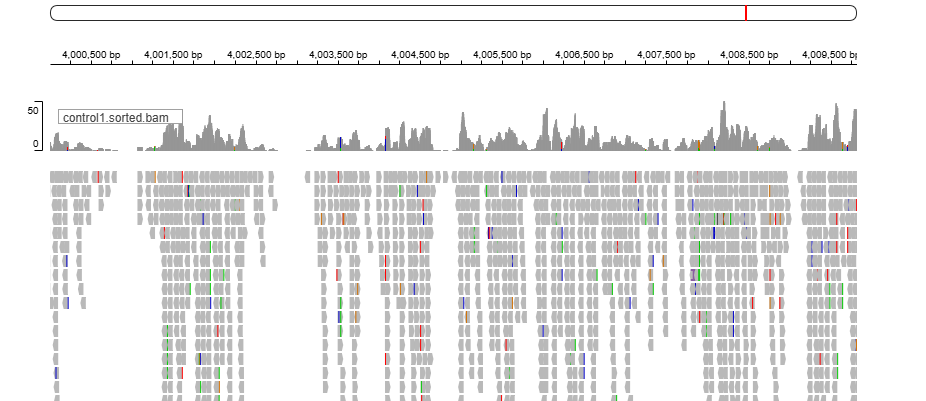

## Afsluiting

Je hebt vandaag een start gemaakt aan een Transcriptomics analyse. Je hebt reads van drie behandelde samples en drie controle samples gemapt tegen een referentiegenoom. Dit referentiegenoom heb je geïndexeerd. De gemapte reads hebben we gevisualiseerd. De volgende keer gaan we bepalen op welke genen de gemapte reads liggen. Hiervoor gebruiken we de .BAM files als input. Deze zijn opgslagen in je huidige working directory.

> Tijdens de casusopdracht ga je een Trancriptomics-analyse uitvoeren met humane samples. In de ruwe data staat zodanig veel informatie, dat het mappen erg lang duurt. Daarom ga je het mappen uitvoeren met subsets (een klein deel van de originele data).

# Werkcollege 2: Count Matrix

Tijdens dit werkcollege gaan we een count matrix maken: een tabel waarin per gen staat hoeveel reads er op dat gen zijn gemapt. Hiervoor gebruiken we weer het `Rsubread` package. Probeer `Rsubread` eerst zelf in te laden. Controleer jezelf met het antwoord hieronder.

**Antwoord**

```r
library(Rsubread)
```

Stel ook weer je working directory in op dezelfde folder als waarin je het vorige werkcollege hebt gewerkt.

```r
setwd("C:/Users/jouw_naam/Documents/Transcriptomics")
```

De stappen die we bij dit tweede werkcollege uit gaan voeren kan je hieronder terugzien.

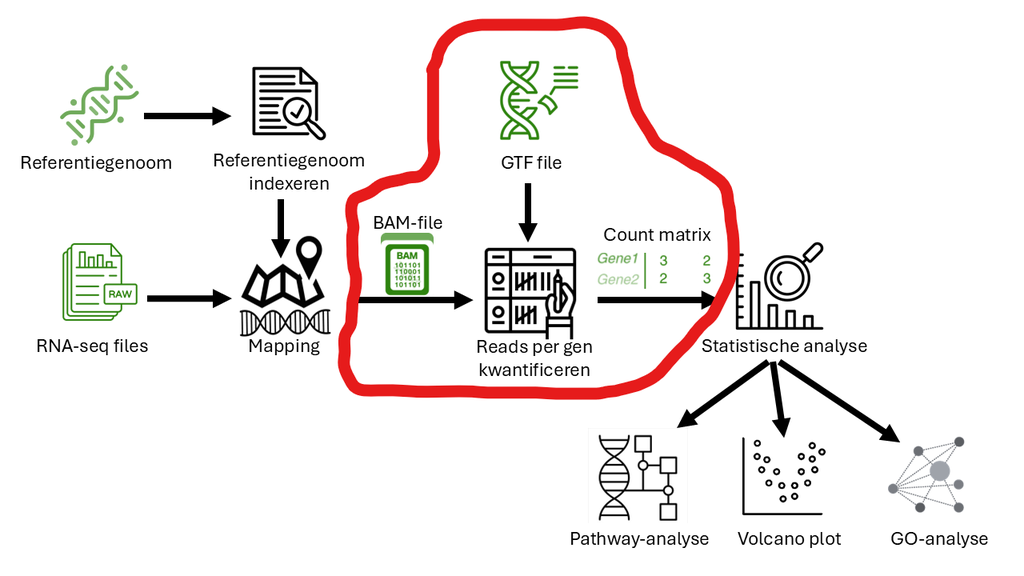

## GTF

Voor het uitvoeren van read-tellingen is een annotatiebestand in GTF-formaat (Gene Transfer Format) vereist. We kunnen referenties zoals een genoom of GTF van *E. coli* bijvoorbeeld vinden op (NCBI)[https://www.ncbi.nlm.nih.gov/datasets/genome/GCF_000005845.2/].

Wat voor informatie kan je vinden in een GTF-bestand? Hieronder kan je een voorbeeld zien van een GTF bestand:

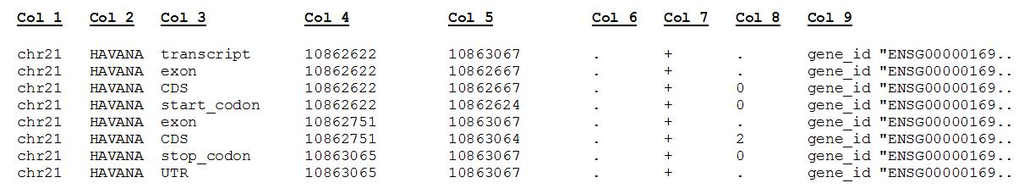

- **Col 1 – Chromosoom**: Op welk chromosoom of contig het element ligt (bv. chr21).
- **Col 2 – Bron**: De bron van de annotatie, bv. HAVANA (een annotatieproject van GENCODE).
- **Col 3 – Feature type**: Type gen-onderdeel, zoals exon, CDS, start_codon, UTR, enz.
- **Col 4 – Startpositie**: Startpositie van het element op het chromosoom.
- **Col 5 – Eindpositie**: Eindpositie van het element.
- **Col 6 – Score**: Score-waarde (meestal een . als er geen score is).
- **Col 7 – Streng**: Op welke DNA-streng het ligt: + (sense) of - (antisense).
- **Col 8 – Frame**: Frame waarin de codon ligt (0, 1, 2) of . als niet van toepassing.
- **Col 9 – Attributen**: Extra info, zoals gene_id, transcript_id, etc. Dit is vaak belangrijk voor read-telling.

> Let erop dat je referenties van verschillende databases kunt downloaden. Er kunnen (kleine) verschillen tussen databases zitten. Daarom is het van belang dat je voor de casus je referentiegenoom en GTF file uit dezelfde database haalt.

## Count matrix één sample

Je gaat nu de uitgelijnde reads (uit de BAM-bestanden) vergelijken met de genannotaties in het GTF-bestand. Op basis van deze vergelijking bepaalt de functie (featureCounts) hoeveel reads er op elk gen vallen. Dit levert een file met ruwe telling per gen op, die later wordt gebruikt voor bijvoorbeeld differentiële expressie-analyse.

Hieronder zie je een code waarmee een count matrix voor één sample wordt gemaakt. Hiervoor wordt de `featureCounts` functie gebruikt.

```r
count_matrix <- featureCounts(
    files = "eth1.BAM",
    annot.ext = "genomic.gtf",
    isPairedEnd = FALSE,
    isGTFAnnotationFile = TRUE,
    GTF.featureType = "gene",
    GTF.attrType = "gene_id",
    useMetaFeatures = TRUE
)
```

Wat gebeurt hier?

Wat is het gevolg van het instellen van useMetaFeatures = TRUE in de functie featureCounts()?

**Antwoord**

Met `useMetaFeatures = TRUE` groepeert featureCounts exons per gen en telt het aantal reads op gen-niveau.

Waarom is het belangrijk om in featureCounts() aan te geven of je reads single-end of paired-end zijn (met isPairedEnd)?

**Antwoord**

Bij paired-end sequencing representeren twee reads één fragment. Je wil voorkomen dat ze dubbel worden geteld.

> Tijdens de casusopdracht ga je een Trancriptomics-analyse uitvoeren met humane samples. Met de zojuist toegevoegde optie `GTF.featureType = "gene"` hebben we alle reads gemapt binnen gen-coördinaten, inclusief intronen. Bij de casus is het verstandig om deze optie weg te laten (kan uit de code gehaald worden), zodat we alleen naar exonen en dus coderende regio’s kijken.

## Count matrix alle samples

We hebben nu voor één file een count matrix gegenereerd. We willen alleen alle files tegelijk opgeven in `featureCounts`, zodat we per sample tellen hoe vaak elk gen voorkomt. Om alle samples tegelijk te kunnen tellen, moeten we een *vector* maken met alle samplenamen. Probeer dit eerst eens zelf.

**Hint**

Met behulp van de *combine* functie kan je meerdere elementen in een lijst zetten:

```r
c("naam", "naam")
```

**Antwoord**

We gebruiken hier `c()` om alle namen van de samples in een vector op te slaan. In dit geval krijgt dit de naam `allsamples`.

```r
allsamples <- c("eth1.BAM", "eth2.BAM", "eth3.BAM", "control1.BAM", "control2.BAM", "control3.BAM")
```

Gebruik nu `featureCounts()` om een count matrix te maken van alle samples. Pas hiervoor de code aan die je gebruikt hebt om een count matrix voor één sample te maken.

**Antwoord**

In plaats van één sample geven we nu de vector met alle samples mee.

```r
count_matrix <- featureCounts(
  files = allsamples,
  annot.ext = "genomic.gtf",
  isPairedEnd = FALSE,
  isGTFAnnotationFile = TRUE,
  GTF.featureType = "gene",
  GTF.attrType = "gene_id",
  useMetaFeatures = TRUE
)
```

## Count matrix bekijken en opslaan

Wat staat er in onze count matrix? We gaan dit verder bekijken.

```r
str(count_matrix)
```

Je ziet dat count_matrix een lijst (list) is met meerdere elementen, waaronder `$counts`, `$annotation`, `$stat`, enz. Voor de volgende stappen heb je alleen de tellingen (de counts) nodig. Een element zoals `counts` is een tabel. Het bevat 4240 rijen en 6 kolommen (te zien als `[1:4240, 1:6]`). We kunnen met `$` een kolom selecteren binnen een tabel. We kunnen ditzelfde teken gebruiken om een element binnen een list te selecteren. We kunnen bijvoorbeeld zo de eerste rijen van het element `annotation` bekijken:

head(count_matrix$annotation)

Probeer nu zelf `counts` op te slaan onder een nieuwe naam.

**Antwoord**

```r
counts <- count_matrix$counts
head(counts)
```

Je ziet per BAM file (kolomnamen) hoeveel reads je per gen (rijnamen) gevonden hebt.

Stel duidelijke kolomnamen in, zodat ze overeenkomen met je samples. Dit helpt bij herkenning tijdens visualisaties en analyses. Het filetype staat er nu nog achter vermeld, dit is dus niet praktisch.

```r
colnames(counts) <- c("eth1", "eth2", "eth3", "control1", "control2", "control3")
head(counts)
```

Nu de matrix klaar is, sla je deze op. Zo kun je hem in Werkcollege 3 direct opnieuw inlezen.

```r
write.csv(counts, "ecoli_countmatrix.csv")
```

## Afsluiting

Je hebt vandaag geleerd hoe je een count matrix genereert met behulp van `Rsubread`. Als input hiervoor heb je de BAM files van werkcollege 1 gebruikt en een annotatiefile. De output heb je opgeslagen zodat je hier de volgende keer verdere analyse mee kunt doen.

> Tijdens de casusopdracht ga je een Trancriptomics-analyse uitvoeren met humane samples. Vanwege de grootte van de samples ga je mappen met subsets en genereer je dus ook een niet-complete count matrix. Wanneer je een count matrix met subsets hebt gemaakt, kan je de volledige count matrix verkrijgen door je script en count matrix (laten zien dat het genereren van counts wel gelukt is d.m.v. een screenshot) naar je tutor sturen. **Deze ‘volledige’ count matrix mag niet onderling uitgewisseld worden, er wordt een lijst bijgehouden wie een script en count matrix heeft ingeleverd. Als je niks hebt ingeleverd wordt er bij het nakijken vanuitgegaan dat de analyse je niet zelfstandig gelukt is.**

# Werkcollege 3: Statistiek en analyse

Tijdens dit werkcollege gaan we de count matrix verder analyseren. We gaan kijken welke genen meer of minder tot expressie komen bij bacteriën die zijn blootgesteld aan ethanol in vergelijking met een controlegroep. Een overzicht van de stappen die we gaan uitvoeren kan je terugzien in onderstaande flowschema.

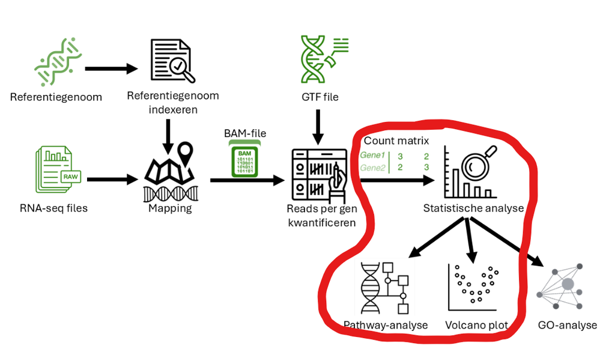

## Omgeving klaarzetten

Zorg er eerst weer voor dat je working directory staat ingesteld op de folder waar je bestanden staan. Laad vervolgens de count matrix in die je aan het einde van het vorige werkcollege hebt opgeslagen met `read.csv()`.

**Tip!** Zorg ervoor dat je bij het inlezen aangeeft dat je data rijnamen bevat. Hoe je dit doet, kan je online opzoeken.

**Antwoord**

```r
# Working directory instellen
setwd("C:/Users/pad/naar/werkcollegefolder/")

# Count matrix inladen
counts <- read.csv("ecoli_countmatrix.csv", row.names = 1)
```

De packages die we vandaag gaan gebruiken zijn [`DESeq2`](https://bioconductor.org/packages/release/bioc/html/DESeq2.html) (voor de statistische analyse), [`KEGGREST`](https://www.bioconductor.org/packages/release/bioc/html/KEGGREST.html) (voor de functionele analyse), [`EnhancedVolcano`](https://bioconductor.org/packages/release/bioc/html/EnhancedVolcano.html) (voor visualisatie) en [`pathview`](https://www.bioconductor.org/packages/release/bioc/html/pathview.html). Kijk eens op de sites van deze packages hoe je ze installeert. Probeer dit uit te voeren en laad daarna de packages in.

**Antwoord**

```r
BiocManager::install("DESeq2")
BiocManager::install("KEGGREST")
BiocManager::install("EnhancedVolcano")
BiocManager::install("pathview")

library(DESeq2)
library(KEGGREST)
library(EnhancedVolcano)
library(pathview)
```

## Metadata

In deze stap maken we een tabel die beschrijft welke monsters behandeld zijn met ethanol en welke als controle dienden. Deze informatie is essentieel voor de differentiële expressieanalyse.

```r
treatment <- c("ethanol", "ethanol", "ethanol", "control", "control", "control")
treatment_table <- data.frame(treatment)
```

Probeer nu zelf de rijnamen van `treatment_table` te veranderen naar de namen van je samples. Zo kan het programma zien tot welke groep elk sample behoort.

**Antwoord**

```r
rownames(treatment_table) <- c('eth1', 'eth2', 'eth3', 'control1', 'control2', 'control3')
```

Bekijk of het maken van de metadata goed is gegaan met behulp van `head()`.

## Statistiek

We maken een DESeqDataSet object aan op basis van de count matrix en de behandelingstabel. Daarna voeren we de differentiële expressie-analyse uit en slaan we de resultaten op. Met de DESeqDataSetFromMatrix zet je alle inputdata die we tot nu toe hebben voorbereid in het juiste format voor de statistische analyse. De nodig input is de count matrix, de zojuist gemaakte informatie over de samples en de kolomnaam waarin de groepering staat die je met elkaar wilt vergelijken.

```r
# Maak DESeqDataSet aan
dds <- DESeqDataSetFromMatrix(countData = counts,
                              colData = treatment_table,
                              design = ~ treatment)
```

Nu we alle data verzameld hebben en in het juist format gezet hebben, kunnen we beginnen met het spannendste gedeelte: de statistiek.

```r
# Voer analyse uit
dds <- DESeq(dds)
resultaten <- results(dds)
```

Zo.

Voor soortgelijke analyses is het van belang te snappen hoe je test ongeveer werkt zodat je correcte statistiek kunt toepassen. Het toepassen zelf is vaak niet erg ingewikkeld en snel klaar zoals je net zag. Hoe werkt de statistiek ongeveer? We willen weten of een bepaald gen meer afgeschreven wordt bij één groep ten opzichte van een andere (in dit geval met alcohol behandeld vs zonder). Hiervoor vergelijken we de getelde reads per gen tussen de groepen.

1. Het kan zijn dat bepaalde samples meer reads in totaal bevatten. Daarvoor corrigeert DESeq met behulp van normalisatie.
2. Genen bevatten natuurlijke variatie (niet alle cellen zijn hetzelfde en sommigen bevatten meer RNA voor een gen dan een andere cel), DESeq gebruikt een model om daar rekening mee te houden in de berekening.
3. Er wordt berekend of het verschil tussen het aantal reads per omstandigheid groter is dan je zou verwachten door toeval, dus of je een significant verschil hebt.
4. Omdat er vaak duizenden genen worden geanalyseerd, wordt er een multiple testing correctie uitgevoerd.

De resultaten uit de test zijn handig op te slaan.

```r
write.table(resultaten, file = 'ResultatenWC3.csv', row.names = TRUE, col.names = TRUE)
```

Bekijk de resultaten eens. Wat zien we hier?

- Rijnamen: Codes van de genen, afhankelijk van de gebruikte database.
- `baseMean`: Gemiddelde van het betreffende gen over alle samples.
- `Log2FoldChange`: Verdubbelingen/halveringen van de testgroep vergeleken met de controlegroep.
- `lfcSE`: Standaardfout van de Log2FoldChange.
- `stat`: De Wald-toets wordt uitgevoerd. Hierbij wordt de `log2FoldChange` gedeeld door de standaardfout hiervan. Om een p-waarde te genereren wordt deze waarde vergeleken met de standaardnormale verdeling.
- `pvalue`: p-waarde (bepaald zoals hierboven beschreven).
- `padj`: Gecorrigeerde p-waarde (standaard volgens Benjamini-Hochberg, aanpasbaar).

Hoeveel genen zijn er écht veranderd? Je kunt dit bijvoorbeeld verduidelijken door te tellen hoeveel genen er significant op- of neer-gereguleerd zijn. In onderstaande voorbeeld tellen we alle genen die differentieel tot expressie komen (gecorrigeerde p-waarde kleiner dan 0.05) bij elkaar op. Dit doen we voor genen die minimaal een verdubbeling hebben laten zien (log2FoldChange > 1) of minimaal een halvering (log2FoldChange < -1)

```r
sum(resultaten$padj < 0.05 & resultaten$log2FoldChange > 1, na.rm = TRUE)
sum(resultaten$padj < 0.05 & resultaten$log2FoldChange < -1, na.rm = TRUE)
```

> Omdat je geen visualisatie krijgt uit deze stap, voelt dit voor je casus overbodig om in je verslag te vermelden. Toch kan informatie over het totaal aantal genen wat differentieel tot expressie komt veel informatie geven aan je lezer. Je kunt hierbij bijvoorbeeld ook ervoor kiezen om een andere log2FoldChange te kiezen.

Welke genen springen eruit? We kunnen bijvoorbeeld wat resultaten sorteren om te kijken naar de opvallendste genen:

```r
hoogste_fold_change <- resultaten[order(resultaten$log2FoldChange, decreasing = TRUE), ]
laagste_fold_change <- resultaten[order(resultaten$log2FoldChange, decreasing = FALSE), ]
laagste_p_waarde <- resultaten[order(resultaten$padj, decreasing = FALSE), ]
```

- `hoogste_fold_change`: zet de genen met de sterkste opregulatie bovenaan.
- `laagste_fold_change`: zet de genen met de sterkste neerregulatie bovenaan.
- `laagste_p_waarde`: zet de genen met de meest significante p-waarden bovenaan.

## Visualisatie: volcano plot

We hebben al een algemeen beeld van de hoeveelheid genen die differentieel tot expressie komen. Een manier hoe we daar wat meer overzicht in kunnen krijgen is met behulp van een volcano plot.

Een volcano plot laat zien welke genen significant veranderen in expressie. Op de x-as staat de log2 fold change en op de y-as de -log10 van de aangepaste p-waarde (padj).

```r
EnhancedVolcano(resultaten,
                lab = rownames(resultaten),
                x = 'log2FoldChange',
                y = 'padj')
```

[output not shown]

Wat geeft de x-as (log2FoldChange) weer in een volcano plot van een differentiële expressie-analyse?

**Antwoord**

De x-as toont de log2 fold change: positieve waarden betekenen upregulatie, negatieve downregulatie tussen condities.

Wat betekent het als een gen een log2 fold change (log2FC) heeft van +2?

**Antwoord**

Een log2FC van +2 betekent dat het gen 2^2 = 4 keer meer tot expressie is gekomen in de behandeling dan in de controle. Omdat het om de log2 gaat, betekent een getal van 2 twee verdubbelingen ten opzichte van de controlegroep en -2 twee halveringen ten opzichte van de controlegroep.

Kijkend naar je Volcano plot, welk gen heeft dan de laagste p-waarde?

**Antwoord**

Wat is er met de genen aan de hand die nu blauw zijn weergegeven?

**Antwoord**

Deze genen zijn statistisch significant (lage p-waarde) differentieel tot expressie gekomen, maar hebben een kleine verandering in expressie. Ze vallen dus buiten de gekozen log2FC-drempel.

Je kunt het figuur opslaan in je working directory met onderstaande code. Je kunt de plot ook opslaan via het ‘Plots’ rechtsonderin RStudio.

```r
dev.copy(png, 'VolcanoplotWC.png',
         width = 8,
         height = 10,
         units = 'in',
         res = 500)
dev.off()
```

> Je hebt tijdens dit werkcollege een ‘standaard’ volcano plot gemaakt. Dit geeft een algemeen beeld van de veranderingen in genexpressie. Je kunt voor je casus kijken op de [github pagina voor het EnhancedVolcano package](https://github.com/kevinblighe/EnhancedVolcano) welke opties je nog meer kunt toevoegen voor verduidelijking van je project. Als je bijvoorbeeld een (set van) genen gaat uitlichten, kan je specifieke labels aan je plot toevoegen.

## Visualisatie: pathway-analyse

Wanneer *E. coli* wordt blootgesteld aan ethanol, laat het onderzoek van Merchel Piovesan Pereira et al. (2020) zien dat verschillende KEGG-pathways verstoord kunnen raken. Hieronder een overzicht van enkele belangrijkste biologische processen (en bijbehorende KEGG pathways)[https://www.kegg.jp/kegg-bin/show_organism?menu_type=pathway_maps&org=eco] die beïnvloed worden door ethanol (ETOH):

Een voorbeeld hiervan is Biofilmvorming (KEGG pathway: Biofilm formation – Escherichia coli (02026)). Genen zoals csrB zijn verhoogd in expressie, wat wijst op biofilmvorming.

Wat is biofilmvorming? Een biofilm is een gestructureerde gemeenschap van bacteriën die zich vasthechten aan een oppervlak en omgeven zijn door een beschermende slijmlaag (extracellulaire matrix). Biofilms maken bacteriën beter bestand tegen stress, zoals ethanol, antibiotica of zuurstofgebrek. Eén van de genen die in het artikel is uitgelicht is CsrB. Als je opzoekt wat voor functie dit gen heeft bij stress, kan je bijvoorbeeld vinden dat overexpressie van dit gen zorgt voor glycogeen accumulatie.

> Je gaat voor de casus een pathway wat meer uitdiepen. Let er dan op welke genen een rol spelen in deze pathways en hoe ze kunnen bijdragen aan het te analyseren onderwerp.

Met `pathview()` maken we een plot van een specifieke KEGG-pathway. In dit voorbeeld gebruiken we “eco02026”, wat biofilmvorming representeert. Als input hebben we alleen de `log2FoldChange` nodig. Deze informatie staat in de tweede kolom van `resultaten`. Om alleen deze kolom over te houden, kunnen we eerst de voorste kolom verwijderen. Daarna kunnen we alle kolommen erachter verwijderen.

```r
resultaten[1] <- NULL
resultaten[2:5] <- NULL

pathview(
  gene.data = resultaten,
  pathway.id = "eco02026",
  species = "eco",
  gene.idtype = "KEGG",
  limit = list(gene = 5)
)
```

Hoe werkt dit?

- `gene.data = resultaten` = We geven aan waarin de informatie staat die pathview kan visualiseren (in ons geval de `log2FoldChange` per gen).
- `pathway.id = "eco02026"` = Te visualiseren KEGG pathway (ID voor Biofilm formation – E. coli in dit geval).
- `species = "eco"` = Organisme wat onderzocht wordt (‘eco’ = *E. coli* in KEGG in dit geval).
- `gene.idtype = "KEGG"` = Geef aan dat het KEGG-ID’s zijn in het geval van deze analyse.
- `limit = list(gene = 5)` = Kleurbereik voor log2FC loopt van -5 tot +5

Hoe ziet de output eruit?

Je hebt een PNG-bestand in je working directory opgeslagen waarin de genen in de pathway rood (upregulated) of groen (downregulated) zijn ingekleurd. Je kunt met behulp van dit soort pathways analyseren welke biologische processen een rol spelen bij bepaalde omstandigheden.

Ook andere pathways worden verstoord wanneer *E. Coli* blootgesteld word aan ethanol.

| Pathway | KEGG pathway | Genen downregulated | Genen upregulated | Betekenis |
| --- | --- | --- | --- | --- |
| Aerobe respiratie en TCA-cyclus | Citrate cycle (TCA cycle) | sdhB, sdhC, gltA | – | Duidt op een verschuiving naar een meer anaerobe toestand |
| Motiliteit en flagelassemblage | Bacterial chemotaxis; Flagellar assembly | fli-, flg-, motA/B-, cheY/Z-series | – | Verminderde motiliteit en chemotaxis; mogelijk energiebesparing |
| Anaeroob metabolisme | Anaerobic respiration | – | cydAB, ompW, glpABC | Past bij een verschuiving naar anaerobe ademhaling |

Je kunt ook ‘andersom zoeken’. Zo kan je bijvoorbeeld kijken of een gen (waar je bijvoorbeeld veel verandering bij ziet) een rol speelt in bepaalde pathways. Onderstaande functie zoekt bijvoorbeeld in welke KEGG-pathways het gen b0221 van Escherichia coli voorkomt.

```r
keggLink("pathway", "eco:b0221")
```

> Je gaat voor de casus een pathway wat meer uitdiepen. Hiervoor kan je zelf een pathway uitkiezen en visualiseren met behulp van bovenstaande codes en KEGG. Het kan lastig zijn om te bepalen welke pathway(s) je verder wilt bekijken. Daarom kan het handig zijn eerst een GO-analyse (zie volgende onderdeel) uit te voeren, zodat je een indicatie krijgt in welke biologische processen de meeste veranderingen optreden.

## GO-analyse

Voor de casusopdracht ga je zelfstandig een Gene Ontology (GO)-analyse uitvoeren. Deze analyse helpt je om inzicht te krijgen in welke biologische processen, moleculaire functies of cellulaire componenten betrokken zijn bij de genen die in jouw dataset een veranderde expressie laten zien.

Een GO-analyse is een veelgebruikte methode om grote lijsten van genen (bijvoorbeeld genen met significante expressieveranderingen) te interpreteren in termen van bekende biologische kennis. Door te onderzoeken welke GO-termen oververtegenwoordigd zijn in jouw lijst met genen, kun je achterhalen welke processen mogelijk beïnvloed worden in je experiment.

Je gaat zelf uitzoeken hoe je deze analyse kunt uitvoeren. Daarbij mag je gebruik maken van bestaande tutorials, packages en voorbeelden als ondersteuning. Hieronder staan twee betrouwbare bronnen die je hierbij kunnen helpen:

GO Enrichment using goseq (UT Austin, https://cloud.wikis.utexas.edu/wiki/spaces/bioiteam/pages/47732482/GO+Enrichment+using+goseq): een stapsgewijze uitleg voor het uitvoeren van GO-analyse met het R-pakket `goseq`.

Gene set testing tutorial (CRUK Summer School, https://bioinformatics-core-shared-training.github.io/cruk-summer-school-2020/RNAseq/extended_html/06_Gene_set_testing.html): een uitgebreidere tutorial over gen-set testing, waaronder GO-analyse.

> Je mag zelf kiezen met welke methode of tool(s) je aan de slag gaat, zolang je je keuzes kunt onderbouwen. Het doel is dat je leert interpreteren welke biologische betekenis de gevonden genen kunnen hebben in de context van je casus.

## Afsluiting

Je hebt tijdens dit laatste werkcollege geanalyseerd of genen differentieel tot expressie komen en hoe je dat kunt visualiseren/interpreteren.

> Je kunt deze werkcolleges als hulpmiddel gebruiken voor de uitvoering van je casusopdracht. Let er dus wel op dat je een aantal onderdelen moet aanpassen en zelf moet uitzoeken. Begin dus op tijd zodat je gedurerde de daarvoor ingeplande momenten je vragen kunt stellen! Houd er hierbij ook rekening mee dat je met een grotere dataset werkt, dus verschillende functies langer de tijd nodig hebben om te runnen.